# Simulation study

Valentin Lauret, Hélène Labach, Matthieu Authier, Olivier Gimenez

Comparing single-visit and repeated-visits integrated occupancy models.

# Methods

Required packages

```r
library(unmarked)
library(tidyverse)
library(cowplot)
```

## Data simulation

### State process

The occupancy state `z` was drawn from a Bernoulli distribution with parameter ψ, `z <- dbern(\psi)`. We wrote ψ as a logistic function of an environmental covariate `cov`:

$logit(\psi) = \alpha_{0} + \alpha_{1} cov$

where $\alpha_{0}$ and $\alpha_{1}$ are unknown parameters that need to be estimated.

We used the `sim_state_cov()` function to simulate the `z` vector that contains the latent ecological state.

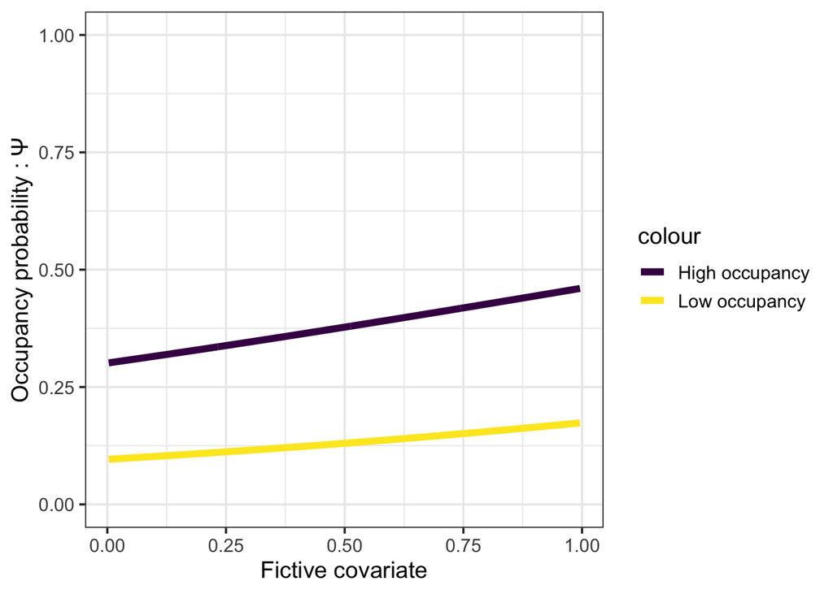

### Obseration process

The observations are drawn either from a Bernoulli distribution with parameter `p` or a Multinomial distribution depending on two detection probability `p1` and `p2` for the integrated occupancy model. We wrote `p` as a logistic function of a sampling effort covariate `seff`:

$logit(p) = \beta_{0} + \beta_{1} seff$

where $\beta_{0}$ and $\beta_{1}$ are unknown parameters that need to be estimated.

We considered two sets of values for the beta’s:

- `beta0 = -0.1` and `beta1 = 0.16` that led to p approx. equal to 0.5
- `beta0 = 1.8` and `beta1 = 0.6` that led to p approx. equal to 0.8

We used the `sim_obs_cov()` function to simulate the `y` vector that contains the detections/non-detections.

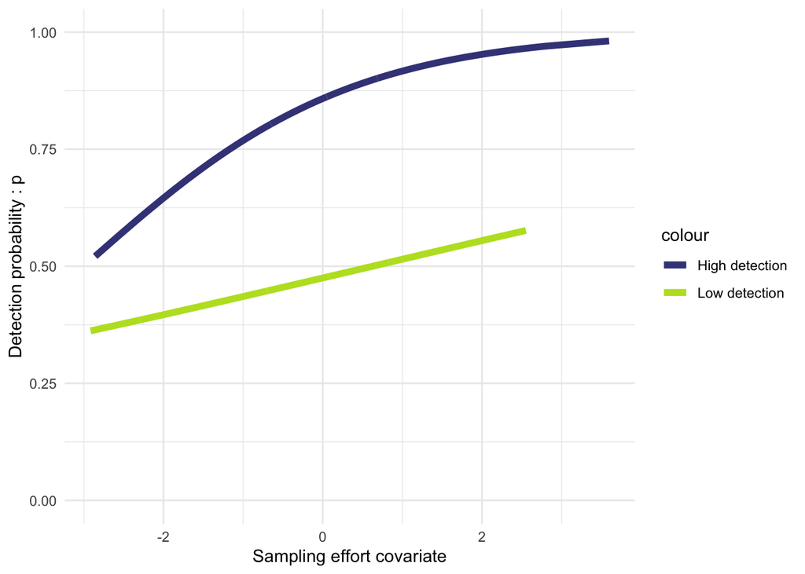

We simulated 4 different sampling occasions for repeated-visit occupancy. For single-visit occupancy, we formatted the data as described in the Methods section. For the sampling effort at site `i`, we summed the sampling effort over the 4 sampling occasions at site `i`, with `seff_sv <- apply(seff_rv,1,sum)`. For the detection/non-detection matrix, we considered the site as occupied if the species was detected at least once over the 4 sampling occasions, with `y_sv <- apply(y_rv,1,max)`.

### Study area

We simulated `z` and `y` for study areas of either 100, or 400 sites.

## Models

We fitted 4 different occupancy models:

- Repeated-visit (RV) single-method occupancy model (SOM) with low detection probability
- Single-visit (SV) single-method occupancy model (SOM) with low detection probability
- Repeated-visits integrated occupancy model (IOM RV), in which we combined two datasets into an integrated occupancy framework
- Single-visit integrated occupancy model (IOM SV)

**Note that for the integrated occupancy, we combined datasets generated from the same `z` ecological states with two different detection probabilities, i.e. we combined one monitoring with 0.5 detection probability (i.e. ‘low p’), and one monitoring with 0.8 detection probability (i.e. ‘high p’).**

## Scenarios

We considered 4 ecological scenarios depending on either the size of the study area or the value of occupancy probability:

- 100 sites with low occupancy;
- 100 sites with high occupancy;
- 400 sites with low occupancy;
- 400 sites high occupancy.

For each scenario, we ran 100 simulations and fitted the 4 occupancy models.

## Performances

To compare the performances of the different occupancy models we calculated the relative bias (RB), and the root mean square error (RMSE) over the `S = 100` simulations :

- Relative bias: $RB = \frac{1}{S} \sum_{1}^{S} \frac{(\widehat{\theta}_{s}-\theta)}{\theta}$
- Root Mean Square Error: $RMSE = \sqrt{ \frac{1}{S} \sum_{1}^{S} (\widehat{\theta}_{s}-\theta)^2}$

# Results

## Occupancy estimation

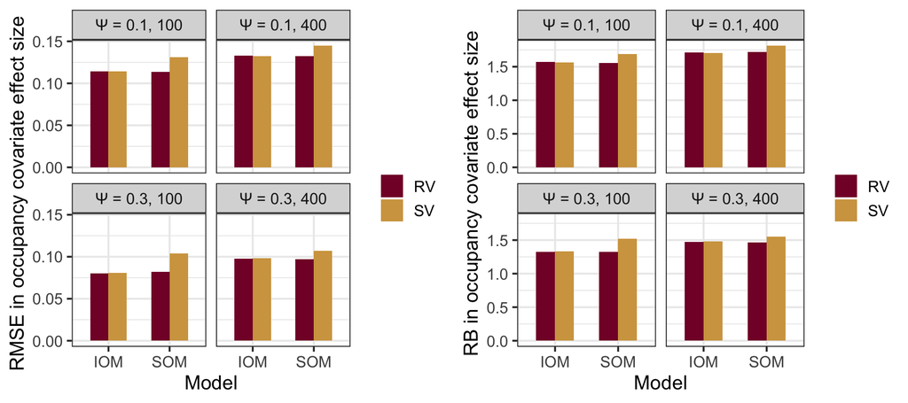

## Detection probability

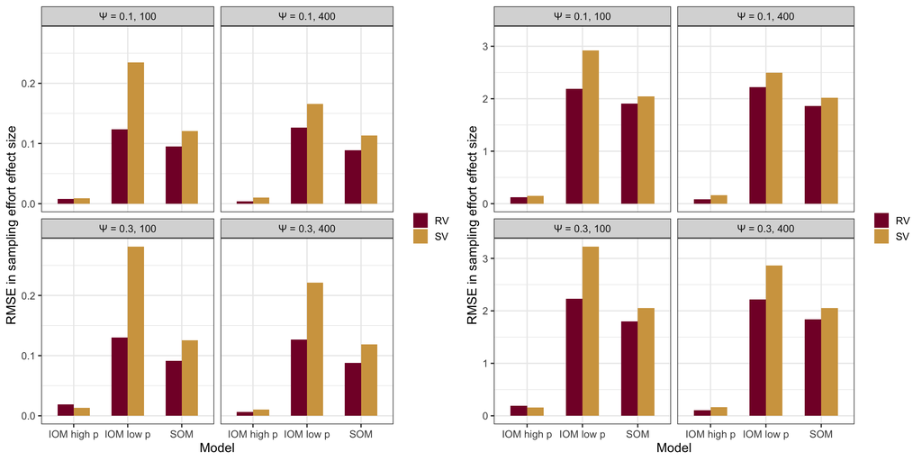

# Discussion